# HW2: PCA for Image Compression

Kate Liu

## Setup

```r
library(readr)

image1 <- data.matrix(read_csv("image1.csv"))
image2 <- data.matrix(read_csv("image2.csv"))
image3 <- data.matrix(read_csv("image3.csv"))
image4 <- data.matrix(read_csv("image4.csv"))

images <- list(image1 = image1, image2 = image2, image3 = image3, image4 = image4)
```

## Image Compression Function

The core of this assignment is a function that takes an image matrix `X` and a rank `k`, and returns the rank-`k` PCA approximation of `X` along with its Frobenius norm reconstruction error.

```r
get_pca_components <- function(X) {
  V <- t(X) %*% X
  eig <- eigen(V)
  U <- eig$vectors
  Z <- X %*% U
  list(U = U, Z = Z, values = eig$values)
}

#Rank-k approximation from precomputed U, Z
approx_k <- function(Z, U, k) {
  Z[, 1:k, drop = FALSE] %*% t(U[, 1:k, drop = FALSE])
}

#Frobenius norm error between X and its approximation
frob_error <- function(X, X_k) {
  norm(X - X_k, type = "F")
}

#rank-k approximation and Frobenius norm error
image_compress <- function(X, k) {
  pca <- get_pca_components(X)
  X_k <- approx_k(pca$Z, pca$U, k)
  error_k <- frob_error(X, X_k)
  list(approx = X_k, error = error_k)
}
```

```r
plot_image <- function(mat, title = "") {
  image(t(apply(mat, 2, rev)), col = grey.colors(256), axes = FALSE, main = title)
}
```

## Analysis Function

```r
analyze_image <- function(X, name) {
  pca <- get_pca_components(X)
  p <- ncol(X)

  #original + first 10 approximations
  par(mfrow = c(3, 4), mar = c(1, 1, 2, 1))
  plot_image(X, paste(name, "- Original"))
  for (k in 1:min(10, p)) {
    Xk <- approx_k(pca$Z, pca$U, k)
    plot_image(Xk, paste0("k = ", k))
  }
  par(mfrow = c(1, 1))

  #error vs. k for all possible k
  errors <- sapply(1:p, function(k) frob_error(X, approx_k(pca$Z, pca$U, k)))
  plot(1:p, errors, type = "b", pch = 16,
       xlab = "k (rank)", ylab = "Frobenius norm error",
       main = paste("Approximation Error vs. k -", name))

  #first eigenvector and first PC score
  par(mfrow = c(1, 2))
  plot(pca$U[, 1], type = "l", main = paste(name, "- 1st Eigenvector"),
       xlab = "Column index", ylab = "Loading")
  plot(pca$Z[, 1], type = "l", main = paste(name, "- 1st PC Score"),
       xlab = "Row index", ylab = "Score")
  par(mfrow = c(1, 1))

  invisible(list(errors = errors, values = pca$values))
}
```

## Image 1

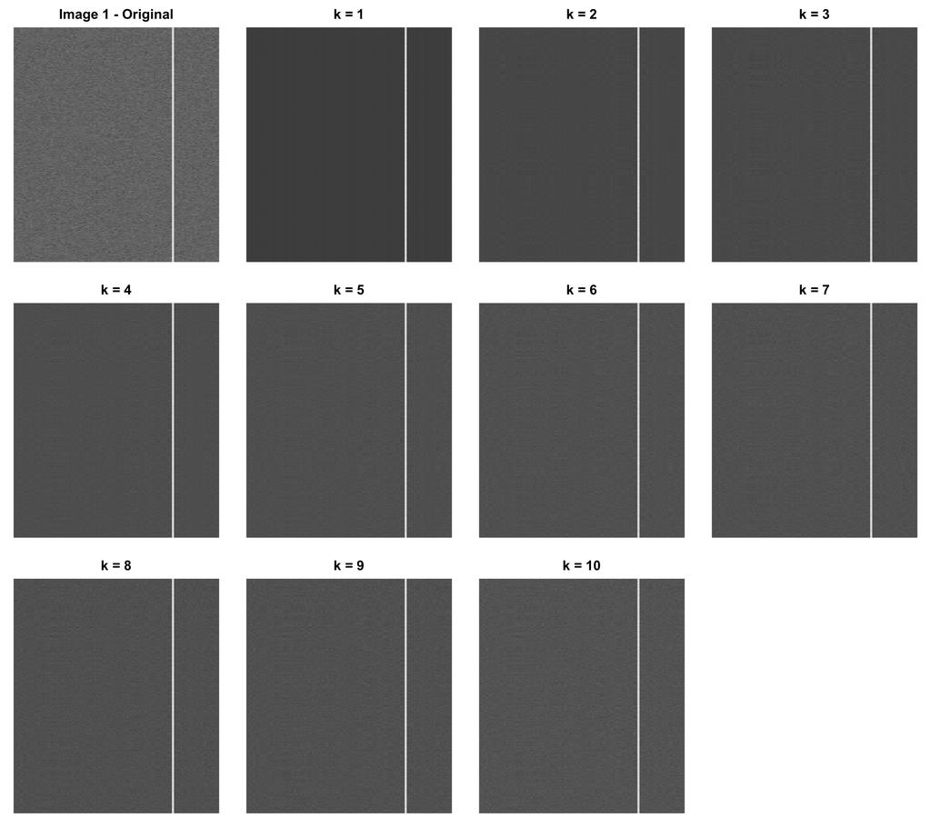

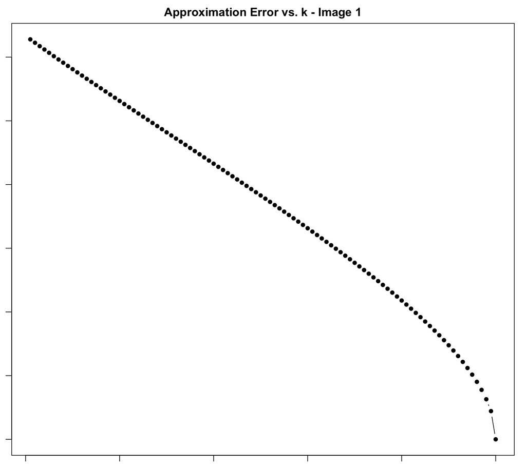

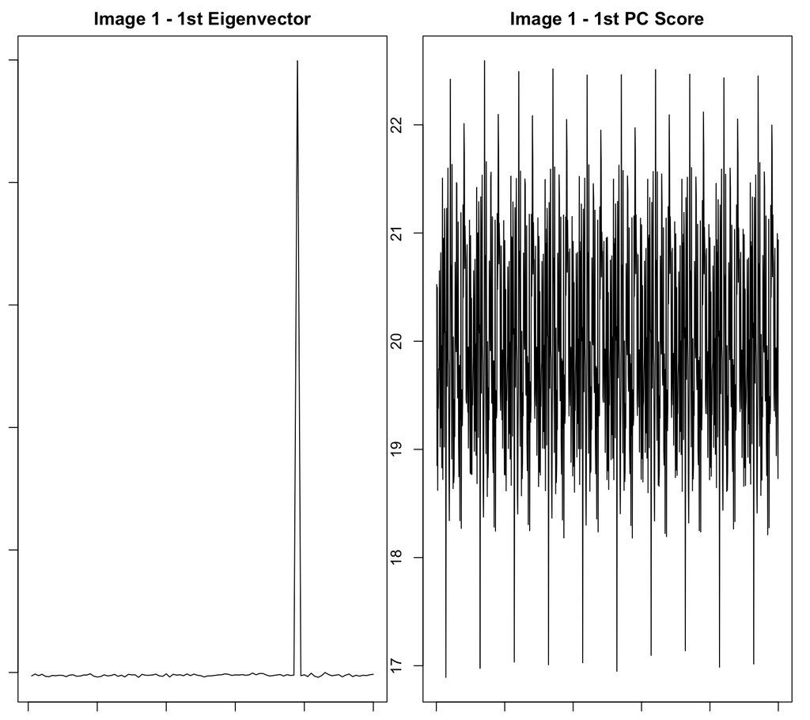

```r
res1 <- analyze_image(image1, "Image 1")
```

**Interpretation:** Image 1 has no visible spatial structure at low rank. The first eigenvector is essentially flat except for one sharp spike, and the first PC score fluctuates without any clear trend across rows. This is consistent with the data being closer to random noise than a real photograph, since the variance is spread out over many components instead of being concentrated in a few dominant ones. As a result, the low-rank approximations look like flat gray blocks rather than recognizable images.

**Opinion on sufficient k:** Because the error curve declines gradually rather than leveling off, there isn’t a small k that captures the image the way there would be for a real photo. A higher k, like k = 40, would help somewhat, but I don’t think there’s really an image to recover here, so no value of k brings back much visual meaning.

## Image 2

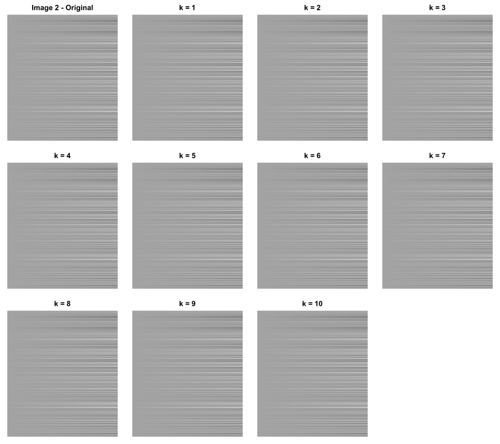

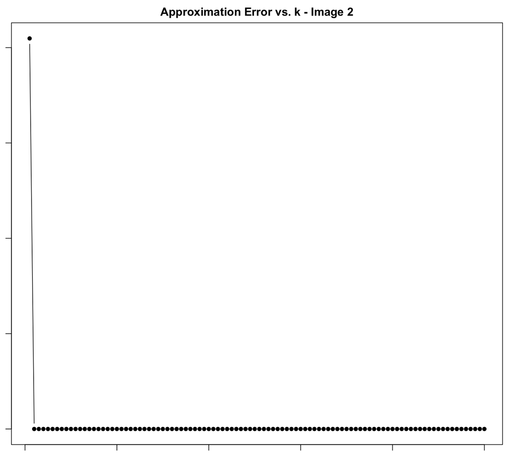

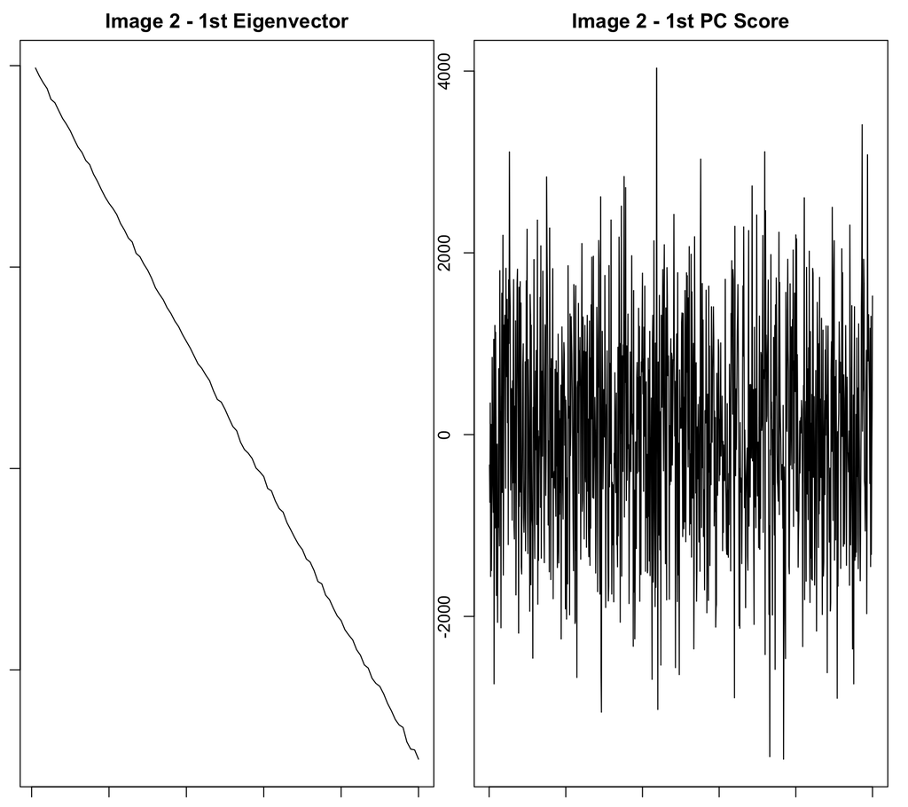

```r
res2 <- analyze_image(image2, "Image 2")
```

**Opinion on sufficient k:** Based on the error curve, k = 2 is good since the error hits close to its floor there and doesn’t meaningfully improve afterward. However, I don’t think there’s a real image being recovered.